# Evaluating Differences in Dam Counts

And Their Effects on DABOM Estimates

Kevin See<sup>1,✉</sup>, and Ben Truscott<sup>1</sup>

February 02, 2022

<sup>1</sup> Washington Department of Fish & Wildlife

<sup>✉</sup> Correspondence: Kevin See <Kevin.See@dfw.wa.gov>

# 1 Introduction

The **D**am **A**dult **B**ranch **O**ccupancy **M**odel (DABOM) has been used to estimate steelhead escapement to various locations around the Upper Columbia for nearly a decade. One of the requirements of this model is an accurate estimate of abundance (possibly with uncertainty) *somewhere* in the system. To this point, we have used dam counts at Priest Rapids Dam to generate that estimate of abundance. We have adjusted the raw counts by an estimated re-ascension rate, to account for fish that may have been counted twice.

Recently, we have called into question the assumption that the dam counts at Priest Rapids are an accurate depiction of how many steelhead are crossing that dam each day. One reason for this questioning is a comparison between the counts at Priest Rapids, and other upstream dams (i.e Rock Island, Rocky Reach and Wells) (Table 1.1). In particular, the fact that the counts were higher at Rock Island dam, the next upstream dam, compared to Priest Rapids, was surprising because there are no major tributaries between Priest Rapids and Rock Island. Between Rock Island and Rocky Reach some steelhead move into the Wenatchee River, and between Rocky Reach and Wells dam some move into the Entiat River, so we expect those counts to shrink as we move upstream.

It is important to acknowledge the various processes going on at and between each dam to help understand these discrepancies. First, although the tagged fish at Priest are assumed to be a representative sample of the steelhead run at large crossing Priest, the proportion of hatchery and natural origin fish may be different at different dams as fish move into different populations at different rates depending on their origin. Second, the re-ascension rate may be (and probably is) different at other dams compared to Priest. However, currently we only have a DART query set up to examine re-ascension at Priest. Therefore, for this exercise we will focus on the equivalent of total fish crossings at Priest (possibly separated by origin).

Table 1.1: Total steelhead dam counts at mainstem dams on the Columbia River from Jun 01, 2020 to May 31, 2021 .

| Dam | Dam Count |
| --- | --- |
| PriestRapids | 6,509 |
| RockIsland | 6,734 |
| RockyReach | 5,397 |
| Wells | 4,391 |

# 2 Methods

For each dam (Rock Island, Rocky Reach, Wells and Tumwater), we started by examining all the tags observed at or upstream of that dam ($j$), by origin ($i$). For each dam, we used these groups of tags to estimate the proportion of each origin of fish that crossed each dam ($\pi_{i,j}$).

$$\pi_{i,j} = \frac{t^{up}_{i,j}}{\sum{t^{up}_j}}$$

We then examined the number of Priest tags detected at each dam (prior to cleaning the detection data with PITcleanr), separated by origin. We inflated this number by the estimated detection probability estimated for each dam by DABOM ($\hat{p}_j$). We then divided this estimated number of tags that had crossed each dam by the total number of tags, by origin, that we started with at Priest. This provides an estimate of the probability that a fish would move from Priest to each dam, by origin ($\psi_{i,j}$).

$$t^{est}_{i,j} = \frac{t^{obs}_{i,j}}{\hat{p}_j} \\
\psi_{i,j} = \frac{t^{est}_{i,j}}{t^{PRD}_i}$$

The next step was to multiply the total dam counts at each dam ($C_j$) by the estimated proportion of origins ($\pi_{i,j}$), then divide each result by the appropriate movement probability ($\psi_{i,j}$). This provides as estimate of the total number of fish, by origin, that crossed Priest, according to the dam count at each dam ($\Gamma_{i,j}$). These estimates by origin can be added to obtain an estimate of the total number of fish that should have been counted at Priest. Using the delta method, the appropriate uncertainty was propogated through this entire process.

$$\Gamma_{i,j} = \frac{C_j * \pi_{i,j}}{\psi_{i,j}} \\
\Gamma_j = \sum_i{\Gamma_{i,j}}$$

# 3 Results

The estimated parameters used in the overall calculations are shown in Table 3.1. The resulting estimates of Priest Dam count equivalents are in Table 3.2, and also presented visually in Figures 3.1 and 3.2. The relative impacts to DABOM estimates of abundance from using a different abundance estimate at Priest Rapids, compared to the original estimate, are shown in Table 3.3.

Table 3.1: Estimated parameters used as inputs for Priest Rapids Dam count equivalents.

| Dam | Origin | $\pi$ | $\psi$ | Total Dam Count (C) |
| --- | --- | --- | --- | --- |
| PriestRapids | H | 0.653 | 1.000 | 6,509 |
| PriestRapids | W | 0.347 | 1.000 | 6,509 |
| RockIsland | H | 0.654 | 0.895 | 6,734 |
| RockIsland | W | 0.346 | 0.869 | 6,734 |
| RockyReach | H | 0.717 | 0.780 | 5,397 |
| RockyReach | W | 0.283 | 0.574 | 5,397 |
| Wells | H | 0.750 | 0.724 | 4,391 |
| Wells | W | 0.250 | 0.454 | 4,391 |
| Tumwater | H | 0.440 | 0.085 | 776 |
| Tumwater | W | 0.560 | 0.202 | 776 |

Table 3.2: Estimates of the equivalent of total counts at Priest Rapids dam, starting with counts at each dam.

Dam

Origin

Dam Count

Priest Count Equiv.

SE

PriestRapids

All

6,509

6,509

RockIsland

All

6,734

7,599

187

RockyReach

All

5,397

7,623

213

Wells

All

4,391

6,968

211

Tumwater

All

776

6,192

475

PriestRapids

H

6,509

4,248

105

RockIsland

H

6,734

4,921

131

RockyReach

H

5,397

4,963

127

Wells

H

4,391

4,548

112

Tumwater

H

776

4,041

438

PriestRapids

W

6,509

2,261

105

RockIsland

W

6,734

2,678

133

RockyReach

W

5,397

2,660

171

Wells

W

4,391

2,421

179

Tumwater

W

776

2,151

184

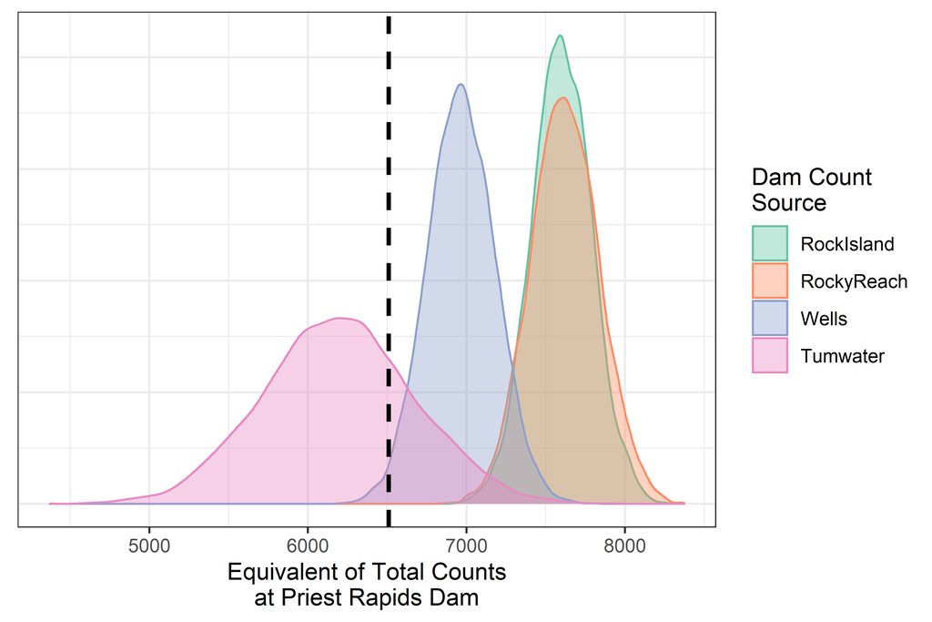

Figure 3.1: Density plot of the estimates of Priest Rapids dam count total equivalents, starting with counts from different dams (colors). Dashed line represents the reported counts at Priest Rapids.

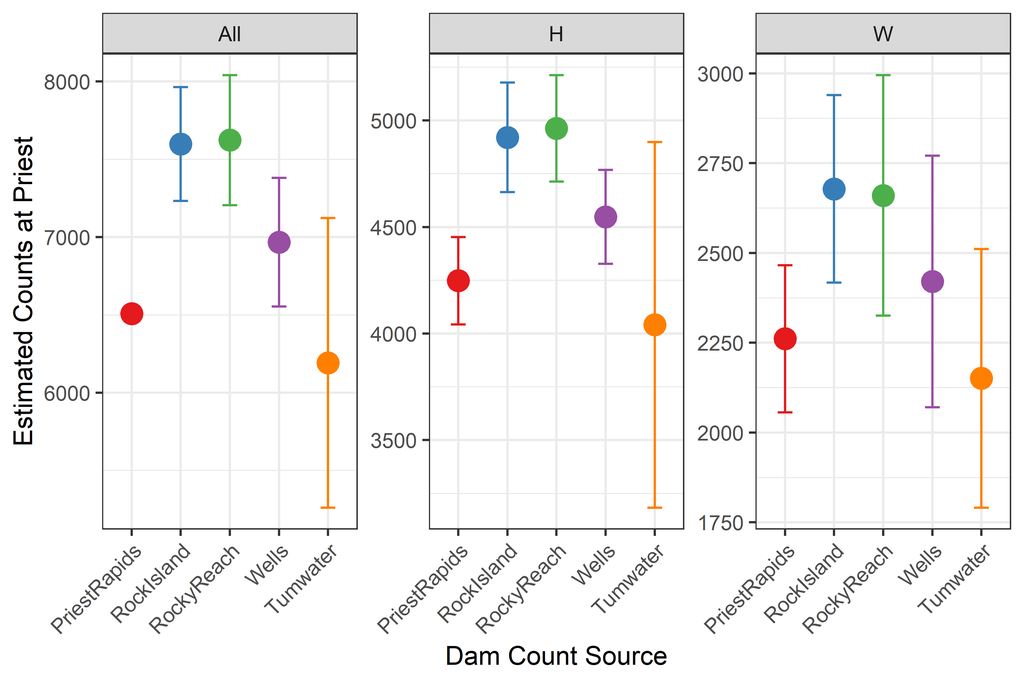

Figure 3.2: Estimated counts at Priest Rapids dam, based on counts from different dams (colors). Facted by origin (or all combined). Errorbars represent 95% confidence intervals.

Table 3.3: Comparison between using original estimate of escapement at Priest by origin with Priest equivalents from various dams. Relative difference would impact all abundance estimates from DABOM equally.

| Dam | Origin | Priest Equiv. | SE | Orginal Priest Est. | Relative Difference (%) |
| --- | --- | --- | --- | --- | --- |
| PriestRapids | H | 4248 | 105 | 4248 | 0.0 |
| PriestRapids | W | 2261 | 105 | 2261 | 0.0 |
| RockIsland | H | 4921 | 131 | 4248 | 15.8 |
| RockIsland | W | 2678 | 133 | 2261 | 18.5 |
| RockyReach | H | 4963 | 127 | 4248 | 16.8 |
| RockyReach | W | 2660 | 171 | 2261 | 17.7 |
| Tumwater | H | 4041 | 438 | 4248 | -4.9 |
| Tumwater | W | 2151 | 184 | 2261 | -4.9 |
| Wells | H | 4548 | 112 | 4248 | 7.1 |
| Wells | W | 2421 | 179 | 2261 | 7.1 |

# 4 Discussion

Using dam counts from either Rock Island or Rocky Reach would increase abundance estimates by approximately 16-18% across both origins, compared to using the original estimates at Priest Rapids dam. Meanwhile, using Wells dam counts would increase abundance estimates by about 7% for both origins. Conversely, using counts from Tumwater would decrease abundance estimates by 5% for both species.

These differences between different dam counts could be caused by problems with the dam counts at some places, but they could also be caused by differences in re-ascension rates between the dams. The total counts at Priest include all the fish that fell back and re-ascended the dam (being counted twice). However, with a re-ascension rate of 3% at Priest, the re-ascension rate would need to be nearly 17% at Rock Island to produce a relative difference of 17% in the Priest equivalent dam count. While that is possible, it seems unlikely to explain all of the differences in counts between Priest and Rock Island (or Rocky Reach).